# Reproducible Research: Peer Assessment 1

## Loading and preprocessing the data

The first step is to load the data and required libraries. This code assumes the *activity.csv* file is in the current working directory. The data is assigned to a data frame called **step.data**.

```r
library(lubridate, warn.conflicts = FALSE)
library(dplyr, warn.conflicts = FALSE)
library(ggplot2, warn.conflicts = FALSE)
fname <- "activity.csv"
step.data <- read.csv(fname)
```

To preprocess this data, we will coerce **step.data$date** to the Date class and create a second data frame called **step.data.nona** with the NA data removed.

```r
step.data <- mutate(step.data, date = ymd(date))
step.data.nona <- step.data[!is.na(step.data$steps),]
```

## What is mean total number of steps taken per day?

To begin understanding the data, we will calculate the total number of steps taken each day and view the results in a histogram. This section ignores the NAs contained in the original data set.

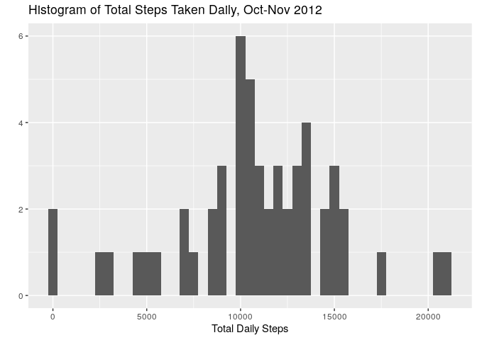

```r
daily.steps <- with(step.data.nona,tapply(steps, date, sum))
steps.mean <- mean(daily.steps)
steps.median <- median(daily.steps)
qplot(daily.steps,binwidth=500,
      xlab="Total Daily Steps",
      main="Histogram of Total Steps Taken Daily, Oct-Nov 2012")
```

The histogram shows that the total number of steps taken on most days is between 10,000 and 15,000. The mean number of steps per day is 10766.19 and the median number of steps per day is 10765.

## What is the average daily activity pattern?

Next, we characterize the average daily activity pattern by plotting the average number of steps taken in each measured interval.

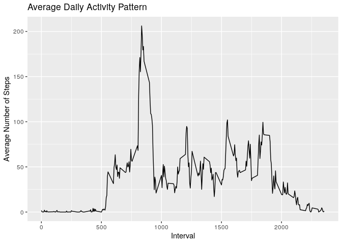

```r
interval.mean <- with(step.data.nona,tapply(steps, interval, mean))
max.interval <- as.numeric(names(which.max(interval.mean)))
qplot(as.numeric(names(interval.mean)),interval.mean,
      geom="line",
      xlab = "Interval",
      ylab = "Average Number of Steps",
      main = "Average Daily Activity Pattern")
```

The maximum average number of steps is 206.1698 and occurs in interval 835.

## Imputing missing values

Now, we will consider the impact of NAs in the original data set.

```r
na.count <- sum(is.na(step.data$steps))
na.pct <- mean(is.na(step.data$steps))*100
```

The original data set contained 2304 NAs. This represents 13.11475% of the data.

Due to the large amount of missing data, we will impute the original data set by replacing NAs with the mean of the interval containing the NA.

```r
step.data.imputed <- step.data
step.data.imputed$interval.mean <- rep(interval.mean,61)
step.data.imputed$steps[is.na(step.data.imputed$steps)] <-
  step.data.imputed$interval.mean[is.na(step.data.imputed$steps)]
```

We will now plot a histogram of the total number of steps each day and recalculate the daily mean and median using the imputed data set.

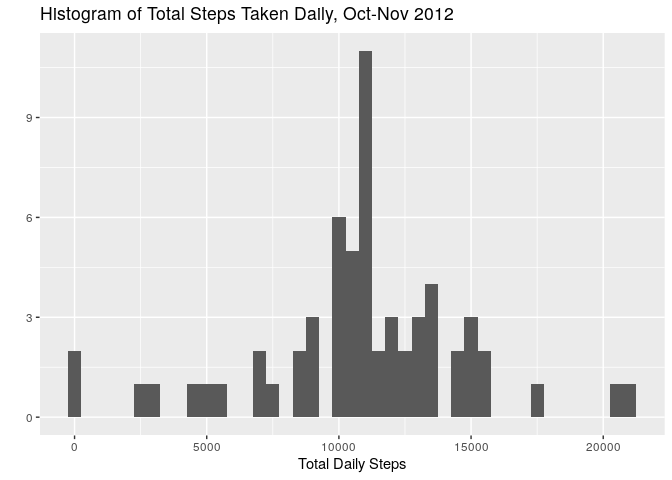

```r
daily.steps.imputed <- with(step.data.imputed,tapply(steps, date, sum))
steps.mean.imputed <- mean(daily.steps.imputed)
steps.median.imputed <- median(daily.steps.imputed)
qplot(daily.steps.imputed,binwidth=500,
      xlab="Total Daily Steps",
      main="Histogram of Total Steps Taken Daily, Oct-Nov 2012")
```

Looking closer at the data set, it is missing data for eight complete days. Replacing each NA with the mean for that interval only reproduced eight average days resulting in no change to the mean or median. The only effect is to reinforce the number of days that express the average in the histogram.

## Are there differences in activity patterns between weekdays and weekends?

Finally, we will look at the variation across days of the week.

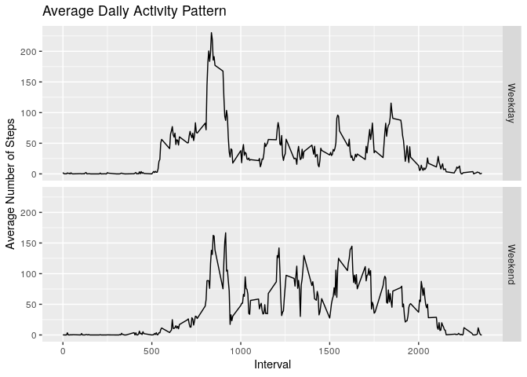

```r
step.data.weekday <- subset(step.data.imputed,
                            weekdays(step.data.imputed$date) %in%
                            list("Monday","Tuesday","Wednesday",
                                 "Thursday","Friday"))
weekday.mean <- with(step.data.weekday,tapply(steps,interval,mean))
weekday.df <- data.frame(steps = weekday.mean,
                         interval = as.numeric(names(weekday.mean)),
                         day.type = as.factor(rep("Weekday",288)))

step.data.weekend <- subset(step.data.imputed,
                            weekdays(step.data.imputed$date) %in%
                            list("Saturday","Sunday"))
weekend.mean <- with(step.data.weekend,tapply(steps,interval,mean))
weekend.df <- data.frame(steps = weekend.mean,
                         interval = as.numeric(names(weekend.mean)),
                         day.type = as.factor(rep("Weekend",288)))

interval.day.mean <- rbind(weekday.df,weekend.df)

qplot(interval,steps,data=interval.day.mean,
      geom = "line", facets = day.type~.,
      xlab = "Interval",
      ylab = "Average Number of Steps",
      main = "Average Daily Activity Pattern")
```

This series of plots shows that the weekend steps start later in the day and are slightly higher throughout much of the day.